# HTML Fundamentals

Diego López Tamayo [^1]

> “Any fool can write code that a computer can understand. Good programmers write code that humans can understand.” — Martin Fowler.

# Introduction to HTML

HTML is the skeleton of all web pages. HTML provides structure to the content appearing on a website, such as images, text, or videos. Right-click on any page on the internet, choose “Inspect,” and you’ll see HTML in a panel of your screen. HTML stands for *HyperText Markup Language*:

- A markup language is a computer language that defines the structure and presentation of raw text.
- In HTML, the computer can interpret raw text that is wrapped in HTML elements.
- HyperText is text displayed on a computer or device that provides access to other text through links, also known as hyperlinks.

Learning HTML is the first step in creating websites, but even a bit of knowledge can help you inject code snippets into newsletter, blog or website templates. As you continue learning, you can layer HTML with CSS and JavaScript to create visually compelling and dynamic websites.

In this notes we’ll use **HTML5**, as it is the current standard.

## HTML Anatomy

HTML is composed of elements. These elements structure the webpage and define its content. Let’s take a look at how they’re written. The diagram displays an HTML paragraph element. As we can see, the paragraph element is made up of:

- An opening tag (< p >)
- The content (“Hello World!”)
- A closing tag (</ p >)

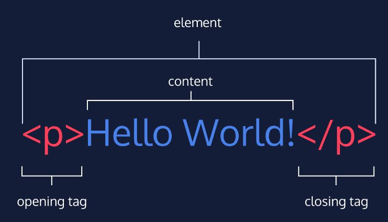

A tag and the content between it is called an HTML element. There are many tags that we can use to organize and display text and other types of content, like images.

Let’s quickly review each part of the element pictured:

- HTML element (or simply, element) — a unit of content in an HTML document formed by HTML tags and the text or media it contains.
- HTML Tag — the element name, surrounded by an opening (<) and closing (>) angle bracket.
- Opening Tag — the first HTML tag used to start an HTML element. The tag type is surrounded by opening and closing angle brackets.
- Content — The information (text or other elements) contained between the opening and closing tags of an HTML element.
- Closing tag — the second HTML tag used to end an HTML element. Closing tags have a forward slash (/) inside of them, directly after the left angle bracket.

## The Body

One of the key HTML elements we use to build a webpage is the body element. Only content inside the opening and closing body tags can be displayed to the screen. Here’s what opening and closing body tags look like:

```r
#  <body>

#  </body>
```

Once the file has a body, many different types of content – including text, images, and buttons – can be added to the body.

```r
#  <body>
#    <p>Some random text</p>
#  </body>
```

## HTML Structure

HTML is organized as a collection of family tree relationships. As you saw in the last exercise, we placed <p> tags within < body > tags. When an element is contained inside another element, it is considered the child of that element. The child element is said to be nested inside of the parent element.

```r
# <body>
#   <p>This paragraph is a child of the body</p>
# </body>
```

You can also see that we’ve added two spaces of indentation (using the space bar) for better readability. Since there can be multiple levels of nesting, this analogy can be extended to grandchildren, great-grandchildren, and beyond. The relationship between elements and their ancestor and descendent elements is known as **hierarchy**.

Let’s consider a more complicated example that uses some new tags:

```r
#  <body>
#    <div>
#      <h1>Sibling to p, also child of div and grandchild of body</h1>
#      <p>Sibling to h1, also child of div and grandchild of body</p>
#    </div>
#  </body>
```

Understanding HTML hierarchy is important because child elements can inherit behavior and styling from their parent element. You’ll learn more about webpage hierarchy when you start digging into CSS.

## Headings

In HTML, there are six different headings, or heading elements. Headings can be used for a variety of purposes, like titling sections, articles, or other forms of content. The following is the list of heading elements available in HTML. They are ordered from largest to smallest in size.

1. < h1 > — used for main headings. All other smaller headings are used for subheadings.
2. < h2 >
3. < h3 >
4. < h4 >
5. < h5 >
6. < h6 >

## Divs

One of the most popular elements in HTML is the <div> element. <div> is short for “division” or a container that divides the page into sections. These sections are very useful for grouping elements in your HTML together.

```r
#  <body>
#    <div>
#      <h1>Why use divs?</h1>
#      <p>Great for grouping elements!</p>
#    </div>
#  </body>
```

<div>s can contain any text or other HTML elements, such as links, images, or videos. Remember to always add two spaces of indentation when you nest elements inside of <div>s for better readability. Notice that visually, there’s no change in the way your html looks, but these divisions are very usefull to divide the sections for later use hyperlinks to each of these sections.

## Attributes

If we want to expand an element’s tag, we can do so using an attribute. Attributes are content added to the opening tag of an element and can be used in several different ways, from providing information to changing styling. Attributes are made up of the following two parts:

- The name of the attribute
- The value of the attribute

One commonly used attribute is the id. We can use the id attribute to specify different content (such as <div>s) and is really helpful when you use an element more than once. ids have several different purposes in HTML, but for now, we’ll focus on how they can help us identify content on our page.

When we add an id to a <div>, we place it in the opening tag:

```r
#  <div id="intro">
#    <h1>Introduction</h1>
#  </div>
```

## Displaying text

If you want to display text in HTML, you can use a paragraph or span:

- Paragraphs (<p>) contain a block of plain text.
- <span> contains short pieces of text or other HTML. They are used to separate small pieces of content that are on the same line as other content.

Example:

```r
#  <div>
#    <h1>Technology</h1>
#  </div>
#  <div>
#    <p><span>Self-driving cars</span> are anticipated to replace up
#      to 2 million jobs over the next two decades.</p>
#  </div>
```

In the example above, there are two different <div>. The second <div> contains a <p> with <span>Self-driving cars</span>.

This <span> element separates “Self-driving cars” from the rest of the text in the paragraph. It’s best to use a <span> element when you want to target a specific piece of content that is inline, or on the same line as other text. If you want to divide your content into blocks, it’s better to use a <div>.

## Styling Text

You can also style text using HTML tags. The <em> tag emphasizes text, while the <strong> tag highlights important text.

Later, when you begin to style websites, you will decide how you want browsers to display content within <em> and <strong> tags. Browsers, however, have built-in style sheets that will generally style these tags in the following ways:

- The <em> tag will generally render as italic emphasis.
- The <strong> will generally render as bold emphasis.

Example:

```r
#  <p><strong>The Nile River</strong> is the <em>longest</em> river in the world,
#  measuring over 6,850 kilometers long (approximately 4,260 miles).</p>
```

In this example, the <strong> and <em> tags are used to emphasize the text to produce the following:

**The Nile River** is the *longest* river in the world, measuring over 6,850 kilometers long (approximately 4,260 miles).

As we can see, “The Nile River” is bolded and “longest” is in italics.

## Line Breaks

The spacing between code in an HTML file doesn’t affect the positioning of elements in the browser. If you are interested in modifying the spacing in the browser, you can use HTML’s line break element: **<br>**. The line break element is unique because it is only composed of a starting tag. You can use it anywhere within your HTML code and a line break will be shown in the browser.

```r
#   <p>The Nile River is the longest river <br> in the world, measuring over 6,850
#   <br> kilometers long (approximately 4,260 <br> miles).</p>
```

The code in the example above will result in an output that looks like the following:

The Nile River is the longest river  
in the world, measuring over 6,850  
kilometers long (approximately 4,260  
miles).

## Unordered Lists

In addition to organizing text in paragraph form, you can also display content in an easy-to-read list. In HTML, you can use an unordered list tag (<ul>) to create a list of items in no particular order. An unordered list outlines individual list items with a bullet point.

The <ul> element should not hold raw text and won’t automatically format raw text into an unordered list of items. Individual list items must be added to the unordered list using the <li> tag. The <li> or list item tag is used to describe an item in a list.

```r
#  <ul>
#    <li>Limes</li>
#    <li>Tortillas</li>
#    <li>Chicken</li>
#  </ul>
```

The output will look like this:

- Limes
- Tortillas
- Chicken

## Ordered Lists

Ordered lists (<ol>) are like unordered lists, except that each list item is numbered. They are useful when you need to list different steps in a process or rank items for first to last. You can create the ordered list with the <ol> tag and then add individual list items to the list using <li> tags.

```r
#  <ol>
#    <li>Preheat the oven to 350 degrees.</li>
#    <li>Mix whole wheat flour, baking soda, and salt.</li>
#    <li>Cream the butter, sugar in separate bowl.</li>
#    <li>Add eggs and vanilla extract to bowl.</li>
#  </ol>
```

The output will look like this:

1. Preheat the oven to 350 degrees.
2. Mix whole wheat flour, baking soda, and salt.
3. Cream the butter, sugar in separate bowl.
4. Add eggs and vanilla extract to bowl.

## Images

All of the elements you’ve learned about so far (headings, paragraphs, lists, and spans) share one thing in common: they’re composed entirely of text! What if you want to add content to your web page that isn’t composed of text, like images?

The <img> tag allows you to add an image to a web page. Most elements require both opening and closing tags, but the <img> tag is a self-closing tag. Note that the end of the <img> tag has a forward slash /. Self-closing tags may include or omit the final slash — both will render properly.

```r
#  <img src="image-location.jpg" />
```

The <img> tag has a required attribute called src. The src attribute must be set to the image’s source, or the location of the image. In this case, the value of src must be the uniform resource locator (URL) of the image. A URL is the web address or local address where a file is stored.

## Image Alts

Part of being an exceptional web developer is making your site accessible to users of all backgrounds. In order to make the Web more inclusive, we need to consider what happens when assistive technologies such as screen readers come across image tags.

The alt attribute, which means “alternative text”, brings meaning to the images on our sites. The alt attribute can be added to the image tag just like the src attribute. The value of alt should be a description of the image.

```r
# <img src="#" alt="A field of yellow sunflowers" />
```

The alt attribute also serves the following purposes:

- If an image fails to load on a web page, a user can mouse over the area originally intended for the image and read a brief description of the image. This is made possible by the description you provide in the alt attribute.
- Visually impaired users often browse the web with the aid of screen reading software. When you include the alt attribute, the screen reading software can read the image’s description out loud to the visually impaired user.
- The alt attribute also plays a role in Search Engine Optimization (SEO), because search engines cannot “see” the images on websites as they crawl the internet. Having descriptive alt attributes can improve the ranking of your site.

If the image on the web page is not one that conveys any meaningful information to a user (visually impaired or otherwise), the alt attribute should be left empty.

## Videos

In addition to images, HTML also supports displaying videos. Like the <img> tag, the <video> tag requires a src attribute with a link to the video source. Unlike the <img> tag however, the <video> element requires an opening and a closing tag.

```r
#  <video src="myVideo.mp4" width="320" height="240" controls> “Video not supported” </video>
```

In this example, the video source (src) is myVideo.mp4 The source can be a video file that is hosted alongside your webpage, or a URL that points to a video file hosted on another webpage.

After the src attribute, the width and height attributes are used to set the size of the video displayed in the browser. The controls attribute instructs the browser to include basic video controls: pause, play and skip.

The text, “Video not supported”, between the opening and closing video tags will only be displayed if the browser is unable to load the video.

# HTML Document Standards.

Now that we’ve learned about some of the most common HTML elements, it’s time to learn how to set up an HTML file. HTML files require certain elements to set up the document properly. We can let web browsers know that we are using HTML by starting our document with a document type declaration.

The declaration looks like this:

```r
#  <!DOCTYPE html>
```

This declaration is an instruction, and it must be the first line of code in your HTML document. It tells the browser what type of document to expect, along with what version of HTML is being used in the document.

In the future, however, a new standard will override HTML5. To make sure your document is forever interpreted correctly, always include <!DOCTYPE html> at the very beginning of your HTML documents.

Lastly, HTML code is always saved in a file with an .html extension.

## The <html> tag

To create HTML structure and content, we must add opening and closing < html > tags after declaring <!DOCTYPE html> :

```r
#  <!DOCTYPE html>
#  <html>

#  </html>
```

Anything between the opening and closing html tags will be interpreted as HTML code. Without these tags, it’s possible that browsers could incorrectly interpret your HTML code.

## The Head

So far you’ve done two things to set up the file properly:

- Declared to the browser that your code is HTML with <!DOCTYPE html>
- Added the HTML element (<html>) that will contain the rest of your code.

This very same page has it’s own DOCTYPE and html tags.

Now, let’s also give the browser some information about the page itself. We can do this by adding a <head> element.

Remember the <body> tag? The <head> element is part of this HTML metaphor. It goes above our <body> element.

The <head> element contains the **metadata** for a web page. Metadata is information about the page that isn’t displayed directly on the web page. Unlike the information inside of the <body> tag, the metadata in the head is information about the page itself. You’ll see an example of this in the next exercise.

The opening and closing head tags typically appear as the first item after your first HTML tag:

```r
#  <html>
#  <head>
#  </head>
#    <body>
#    <\body>
#  </html>
```

## Page Titles

What kind of metadata about the web page can the <head> element contain?

If you browse for example [Diego Tamayo website](https://diego-eco.github.io/) your browser will open a new tab and you’ll see Diego Tamayo displayed on the tab. That’s the title of the webpage.

A browser’s tab displays the title specified in the <title> tag. The <title> tag is always inside of the <head>.

```r
#  <html>
#  <head>
#     <title> My website's title </title>
#  </head>
#    <body>
#    <\body>
#  </html>
```

[figure not shown]

## Linking to Other Web Pages

One of the powerful aspects of HTML (and the Internet), is the ability to link to other web pages.

You can add links to a web page by adding an anchor element **<a>** and including the text of the link in between the opening and closing tags.

```r
#   <a href="https://www.wikipedia.org/">This Is A Link To Wikipedia</a>
```

The example looks like this:

[This Is A Link To Wikipedia](https://www.wikipedia.org/)

When reading technical documentation, you may come across the term hyperlink. Not to worry, this is simply the technical term for link. These terms are often used interchangeably.

## Opening Links in a New Window

Have you ever clicked on a link and observed the resulting web page open in a new browser window? If so, you can thank the <a> element’s target attribute. The target attribute specifies how a link should open. It’s possible that one or more links on your web page link to an entirely different website. In that case, you may want users to read the linked website, but hope that they return to your web page. This is exactly when the target attribute is useful!

For a link to open in a new window, the target attribute requires a value of _blank. The target attribute can be added directly to the opening tag of the anchor element, just like the href attribute.

```r
# <a href="https://en.wikipedia.org/wiki/Brown_bear" target="_blank">The Brown Bear</a>
```

The example looks like this, try it and compare it with the last hyperlink:

[The Brown Bear](https://en.wikipedia.org/wiki/Brown_bear)

In the example above, setting the target attribute to "_blank" instructs the browser to open the relevant Wikipedia page in a new window. In this exercise, we’ve used the terminology “open in a new window.” It’s likely that you are using a modern browser that opens up websites in new tabs, rather than new windows. Before the advent of browsers with tabs, additional browser windows had to be opened to view more websites. The target="_blank" attribute, when used in modern browsers, will open new websites in a new tab.

## Linking to Relative Page

Thus far you have learned how to link to external web pages. Many sites also link to internal web pages like Home, About, and Contact.

Before we learn how to link between internal pages, let’s establish where our files are stored. When making multi-page static websites, web developers often store HTML files in the root directory, or a main folder where all the files for the project are stored. As the size of the projects you create grows, you may use additional folders within the main project folder to organize your code.

Example:

```r
#  project-folder/
#  |—— about.html
#  |—— contact.html
#  |—— index.html
```

The example above shows three different files : about.html, contact.html, and index.html in one folder.

HTML files are often stored in the same folder, as shown in the example above. If the browser is currently displaying index.html, it also knows that about.html and contact.html are in the same folder. Because the files are stored in the same folder, we can link web pages together using a **relative path**.

```r
#  <a href="./contact.html">Contact</a>
```

In this example, the <a> tag is used with a relative path to link from the current HTML file to the contact.html file in the same folder. On the web page, Contact will appear as a link.

A relative path is a filename that shows the path to a local file (a file on the same website, such as ./index.html) versus an absolute path (a full URL, like https://diego-eco.github.io/files/minim_costos.html which is stored in a different folder named “files”). The **./** in ./index.html tells the browser to look for the file in the current folder.

## Linking At Will

You’ve probably visited websites where not all links were made up of text. Maybe the links you clicked on were images or some other form of content. So far, we’ve added links that were made up of only text. Text-only links, however, would significantly decrease your flexibility as a web developer!

[figure not shown]

```r
# <a href="link_url" target="_blank"><img src="image_url" alt="alternative_image_description"/></a>
```

## Linking to Same Page

At this point, we have all the content we want on our page. Since we have so much content, it doesn’t all fit on the screen. How do we make it easier for a user to jump to different portions of our page?

When users visit our site, we want them to be able to click a link and have the page automatically scroll to a specific section. In order to link to a target on the same page, we must give the target an id, like this:

```r
# <p id="top">This is the top of the page!</p>
# <h1 id="bottom">This is the bottom! </h1>
```

Notice we’re adding id’s to different elements. An id can be added to most elements on a webpage. An id should be descriptive to make it easier to remember the purpose of a link. The target link is a string containing the # character and the target element’s id. An id is especially helpful for organizing content belonging to a div!

For example, we could create an unordered list under the <h1> tag (our website title) anchoring each element of the list into a already id:# section in our website. This is a simple way to have a “navigation bar” at the top of our website.

```r
#  <ul>
#    <li><a href="#introduction">Introduction</a></li>
#    <li><a href="#middle">Middle</a></li>
#    <li><a href="#end">End</a></li>
#   </ul>
```

## Whitespace

Now we’ll focus on some tools developers use to make code easier to interpret. As the code in an HTML file grows, it becomes increasingly difficult to keep track of how elements are related. Programmers use two tools to visualize the relationship between elements: *whitespace* and *indentation*.

Both tools take advantage of the fact that the position of elements in a browser is independent of the amount of whitespace or indentation in the index.html file. For example, if you wanted to increase the space between two paragraphs on your web page, you would not be able to accomplish this by adding space between the paragraph elements in the index.html file. The browser ignores whitespace in HTML files when it renders a web page, so it can be used as a tool to make code easier to read and follow.

What makes the example below difficult to read?

```r
#  <body><p>Paragraph 1</p><p>Paragraph 2</p></body>
```

You have to read the entire line to know what elements are present. Compare the example above to this:

```r
#  <body>
#      <p>Paragraph 1</p>
#      <p>Paragraph 2</p>
#  </body>
```

This example is easier to read, because each element is on its own line. While the first example required you to read the entire line of code to identify the elements, this example makes it easy to identify the body tag and two paragraphs. A browser renders both examples the same way.

## Indentation

The second tool web developers use to make the structure of code easier to read is indentation. The spaces are inserted using the space and tab bars on your keyboard.

The World Wide Web Consortium, or W3C, is responsible for maintaining the style standards of HTML. At the time of writing, the W3C recommends 2 spaces of indentation when writing HTML code. Although your code will work without exactly two spaces, this standard is followed by the majority of professional web developers. Indentation is used to easily visualize which elements are nested within other elements.

```r
#    <body>
#      <p>Paragraph 1</p>
#      <div>
#        <p>Paragraph 2</p>
#      </div>
#    </body>
```

In the example above, Paragraph 1 and the div tag are nested inside of the body tag, so they are indented two spaces. The Paragraph 2 element is nested inside of the div tag, so it is indented an additional two spaces.

## Comments

HTML files also allow you to add comments to your code. Comments begin with <!– and end with –>. Any characters in between will be ignored by your browser.

Including comments in your code is helpful for many reasons:

- They help you (and others) understand your code if you decide to come back and review it at a much later date.
- They allow you to experiment with new code, without having to delete old code.

```r
# <!-- <p> Test Code </p> -->
```

In the example above, a valid HTML element (a paragraph element) has been “commented out.” This practice is useful when there is code you want to experiment with, or return to, in the future.

## HTML Tags

You now know all of the basic elements and set-up you need to structure an HTML page and add different types of content. With the help of CSS, very soon you’ll be creating beautiful websites!

While some tags have a very specific purpose, such as image and video tags, most tags are used to describe the content that they surround, which helps us modify and style our content later. There are seemingly infinite numbers of tags to use (many more than we’ve taught). Knowing when to use each one is based on how you want to describe the content of your HTML. Descriptive, well-chosen tags are one key to high-quality web development. A full list of available HTML tags can be found in [Mozilla documentation](https://developer.mozilla.org/en-US/docs/Web/HTML/Element)

Let’s review what you’ve learned:

- The <!DOCTYPE html> declaration should always be the first line of code in your HTML files. This lets the browser know what version of HTML to expect.
- The <html> element will contain all of your HTML code.
- Information about the web page, like the title, belongs within the <head> of the page.
- You can add a title to your web page by using the <title> element, inside of the head.
- A webpage’s title appears in a browser’s tab.
- Anchor tags (<a>) are used to link to internal pages, external pages or content on the same page.
- You can create sections on a webpage and jump to them using <a> tags and adding ids to the elements you wish to jump to.
- Whitespace between HTML elements helps make code easier to read while not changing how elements appear in the browser.
- Indentation also helps make code easier to read. It makes parent-child relationships visible.
- Comments are written in HTML using the following syntax: <!– comment –>.

# Tables

## Introduction to Tables

There are many websites on the Internet that display information like stock prices, sports scores, invoice data, and more. This data is naturally tabular in nature, meaning that a table is often the best way of presenting the data.

In this part, we’ll learn how to use the HTML <table> element to present information in a two-dimensional table to the users.

## Create a table

Before displaying data, we must first create the table that will contain the data by using the <table> element.

```r
# <table>

# </table>
```

## Table Rows

In many programs that use tables, the table is already predefined for you, meaning that it contains the rows, columns, and cells that will hold data. In HTML, all of these components must be created.

The first step in entering data into the table is to add rows using the table row element: <tr>. In the example above, two rows have been added to the table.

```r
#  <table>
#    <tr>
#    </tr>
#    <tr>
#    </tr>
#  </table>
```

## Table Data

Rows aren’t sufficient to add data to a table. Each cell element must also be defined. In HTML, you can add data using the table data element: <td>.

```r
#  <table>
#    <tr>
#      <td>73</td>
#      <td>81</td>
#    </tr>
#  </table>
```

In the example above, two data points (73 and 81) were entered in the one row that exists. By adding two data points, we created two cells of data.

## Table Headings

Table data doesn’t make much sense without titles to describe what the data represents.

To add titles to rows and columns, you can use the table heading element: <th>. The table heading element is used just like a table data element, except with a relevant title. Just like table data, a table heading must be placed within a table row.

```r
#  <table>
#    <tr>
#      <th></th>
#      <th scope="col">Saturday</th>
#      <th scope="col">Sunday</th>
#    </tr>
#    <tr>
#      <th scope="row">Temperature</th>
#      <td>73</td>
#      <td>81</td>
#    </tr>
#  </table>
```

Example:

|  | Saturday | Sunday |
| --- | --- | --- |
| Temperature | 73 | 81 |

What happened in the code above? First, a new row was added to hold the three headings: a blank heading, a Saturday heading, and a Sunday heading. The blank heading creates the extra table cell necessary to align the table headings correctly over the data they correspond to. In the second row, one table heading was added as a row title: Temperature.

Note, also, the use of the scope attribute, which can take one of two values:

- row this value makes it clear that the heading is for a row.
- col this value makes it clear that the heading is for a column.

HTML code for tables may look a little strange at first, but analyzing it piece by piece helps make the code more understandable.

## Table Borders

So far, the tables you’ve created have been a little difficult to read because they have no borders. In older versions of HTML, a border could be added to a table using the border attribute and setting it equal to an integer. This integer would represent the thickness of the border.

```r
#  <table border="1">
#    <tr>
#      <td>73</td>
#      <td>81</td>
#    </tr>
#  </table>
```

The code in the example above is following is deprecated, so please don’t use it. It’s meant to illustrate older conventions you may come across when reading other developers’ code.

The browser will likely still interpret your code correctly if you use the border attribute, but that doesn’t mean the attribute should be used. We use CSS [Cascading Style Sheets](https://en.wikipedia.org/wiki/Cascading_Style_Sheets) to add style to HTML documents, because it helps us to separate the structure of a page from how it looks. You can achieve the same table border effect using CSS.

```r
#  table, td {
#    border: 1px solid black;
#  }
```

The code in the example above uses CSS instead of HTML to show table borders.

What if the table contains data that spans multiple columns? For example, a personal calendar could have events that span across multiple hours, or even multiple days. Data can span columns using the **colspan** attribute. The attributes accepts an integer (greater than or equal to 1) to denote the number of columns it spans across.

```r
#  <table>
#    <tr>
#      <th>Monday</th>
#      <th>Tuesday</th>
#      <th>Wednesday</th>
#    </tr>
#    <tr>
#      <td colspan="2">Out of Town</td>
#      <td>Back in Town</td>
#    </tr>
#  </table>
```

| Monday | Tuesday | Wednesday |
| --- | --- | --- |
| Out of Town |  | Back in Town |

In the example above, the data Out of Town spans the Monday and Tuesday table headings using the value 2 (two columns). The data Back in Town appear only under the Wednesday heading.

## Spanning Rows.

Data can also span multiple rows using the **rowspan** attribute. The rowspan attribute is used for data that spans multiple rows (perhaps an event goes on for multiple hours on a certain day). It accepts an integer (greater than or equal to 1) to denote the number of rows it spans across.

```r
#  <table>
#    <tr> <!-- Row 1 -->
#      <th></th>
#      <th>Saturday</th>
#      <th>Sunday</th>
#    </tr>
#    <tr> <!-- Row 2 -->
#      <th>Morning</th>
#      <td rowspan="2">Work</td>
#      <td rowspan="3">Relax</td>
#    </tr>
#    <tr> <!-- Row 3 -->
#      <th>Afternoon</th>
#    </tr>
#    <tr> <!-- Row 4 -->
#      <th>Evening</th>
#      <td>Dinner</td>
#    </tr>
#  </table>
```

[output not shown]

In the example above, there are four rows:

1. The first row contains an empty cell and the two column headings.
2. The second row contains the Morning row heading, along with Work, which spans two rows under the Saturday column. The “Relax” entry spans three rows under the Sunday column.
3. The third row only contains the Afternoon row heading.
4. The fourth row only contains the Dinner entry, since “Relax” spans into the cell next to it.

## Table Body

Over time, a table can grow to contain a lot of data and become very long. When this happens, the table can be sectioned off so that it is easier to manage. Long tables can be sectioned off using the table body element: **<tbody>**. The <tbody> element should contain all of the table’s data, excluding the table headings (more on this in a later exercise).

```r
#  <table>
#    <tbody>
#      <tr>
#        <th></th>
#        <th>Saturday</th>
#        <th>Sunday</th>
#      </tr>
#      <tr>
#        <th>Morning</th>
#        <td rowspan="2">Work</td>
#        <td rowspan="3">Relax</td>
#      </tr>
#      <tr>
#       <th>Afternoon</th>
#      </tr>
#      <tr>
#        <th>Evening</th>
#        <td>Dinner</td>
#      </tr>
#    </tbody>
#  </table>
```

In the example above, all of the table data is contained within a table body element. Note, however, that the headings were also kept in the table’s body.

## Table Head

In the last exercise, the table’s headings were kept inside of the table’s body. When a table’s body is sectioned off, however, it also makes sense to section off the table’s column headings using the **<thead>** element.

```r
#  <table>
#    <thead>
#      <tr>
#        <th></th>
#        <th scope="col">Saturday</th>
#        <th scope="col">Sunday</th>
#      </tr>
#    </thead>
#    <tbody>
#      <tr>
#        <th scope="row">Morning</th>
#        <td rowspan="2">Work</td>
#        <td rowspan="3">Relax</td>
#      </tr>
#      <tr>
#       <th scope="row">Afternoon</th>
#      </tr>
#      <tr>
#        <th scope="row">Evening</th>
#        <td>Dinner</td>
#      </tr>
#    </tbody>
#  </table>
```

In the example above, the only new element is **<thead>**. The table headings are contained inside of this element. Note that the table’s head still requires a row in order to contain the table headings.

Additionally, only the column headings go under the <thead> element. We can use the scope attribute on <th> elements to indicate whether a <th> element is being used as a “row” heading or a “col” heading. Notice that all of these is for code purpose only, it does not change visually the table.

## Table Footer

The bottom part of a long table can also be sectioned off using the **<tfoot>** element.

```r
#  <table>
#    <thead>
#      <tr>
#        <th>Quarter</th>
#        <th>Revenue</th>
#        <th>Costs</th>
#      </tr>
#    </thead>
#    <tbody>
#      <tr>
#        <th>Q1</th>
#        <td>$10M</td>
#        <td>$7.5M</td>
#      </tr>
#      <tr>
#        <th>Q2</th>
#        <td>$12M</td>
#        <td>$5M</td>
#      </tr>
#    </tbody>
#    <tfoot>
#      <tr>
#        <th>Total</th>
#        <td>$22M</td>
#        <td>$12.5M</td>
#      </tr>
#    </tfoot>
#  </table>
```

| Quarter | Revenue | Costs |
| --- | --- | --- |
| Q1 | $10M | $7.5M |
| Q2 | $12M | $5M |
| Total | $22M | $12.5M |

In the example above, the footer contains the totals of the data in the table. Footers are often used to contain sums, differences, and other data results.

## Styling with CSS

Tables, by default, are very bland. They have no borders, the font color is black, and the typeface is the same type used for other HTML elements. You can use CSS to style tables. Specifically, you can style the various aspects mentioned above.

```r
#  table, th, td {
#    border: 1px solid black;
#    font-family: Arial, sans-serif;
#    text-align: center;
#  }
```

The code in the example above demonstrates just some of the various table aspects you can style using CSS properties.

Let’s review what we’ve learned so far:

- The <table> element creates a table.
- The <tr> element adds rows to a table.
- To add data to a row, you can use the <td> element.
- Table headings clarify the meaning of data. Headings are added with the <th> element.
- Table data can span columns using the colspan attribute.
- Table data can span rows using the rowspan attribute.
- Tables can be split into three main sections: a head, a body, and a footer.
- A table’s head is created with the <thead> element.
- A table’s body is created with the <tbody> element.
- A table’s footer is created with the <tfoot> element.
- All the CSS properties you learned about in this course can be applied to tables and their data.

# HTML Forms

## Introduction

Forms are a part of everyday life. When we use a physical form in real life, we write down information and give it to someone to process. Think of the times you’ve had to fill out information for various applications like a job, or a bank account, or dropped off a completed suggestion card — each instance is a form!

Just like a physical form, an HTML **<form>** element is responsible for collecting information to send somewhere else. Every time we browse the internet we come into contact with many forms and we might not even realize it. There’s a good chance that if you’re typing into a text field or providing an input, the field that you’re typing into is part of a **<form>**!

In this section, we’ll go over the structure and syntax of a <form> and the many elements that populate it.

## How a Form Works

We can think of the internet as a network of computers which send and receive information. Computers need an HTTP request to know how to communicate. The HTTP request instructs the receiving computer how to handle the incoming information. More information can be found in this article about [HTTP requests](https://www.codecademy.com/articles/http-requests).

The <form> element is a great tool for collecting information, but then we need to send that information somewhere else for processing. We need to supply the <form> element with both the location of where the <form>‘s information goes and what HTTP request to make. Take a look at the sample <form> below:

```r
#  <form action="/example.html" method="POST">
#  </form>
```

In the above example, we’ve created the skeleton for a <form> that will send information to example.html as a POST request:

- The action attribute determines where the information is sent.
- The method attribute is assigned a HTTP verb that is included in the HTTP request.

Note: HTTP verbs like POST do not need to be capitalized for the request to work, but it’s done so out of convention. In the example above we could have written method=“post” and it would still work.

The <form> element can also contain child elements. For instance, it would be helpful to provide a header so that users know what this <form> is about. We could also add a paragraph to provide even more detail. Let’s see an example of this in code:

```r
#  <form action="/example.html" method="POST">
#    <h1>Creating a form</h1>
#    <p>Looks like you want to learn how to create an HTML form. Well, the best way to learn is to play around with it.</p>
#  </form>
```

## Text Input

If we want to create an input field in our <form>, we’ll need the help of the **<input>** element. The <input> element has a type attribute which determines how it renders on the web page and what kind of data it can accept.

The first value for the type attribute we’re going to explore is “text”. When we create an <input> element with type=“text”, it renders a text field that users can type into. It’s also important that we include a name attribute for the <input> — without the name attribute, information in the <input> won’t be sent when the <form> is submitted.

```r
#  <form action="/example.html" method="POST">
#    <input type="text" name="first-text-field">
#  </form>
```

After users type into the <input> element, the value of the value attribute becomes what is typed into the text field. The value of the value attribute is paired with the value of the name attribute and sent as text when the form is submitted.

For instance, if a user typed in “important details” in the text field created by our <input> element. When the form is submitted, the text: “first-text-field=important details” is sent to /example.html because the value of the name attribute is “first-text-field” and the value of value is “important details”.

We could also assign a default value for the value attribute so that users have a pre-filled text field when they first see the rendered form like so:

```r
# <form action="/example.html" method="POST">
#   <input type="text" name="first-text-field" value="username">
# </form>
```

## Adding a Label

In the previous exercise we created an <input> element but we didn’t include anything to explain what the <input> is used for. For a user to properly identify an <input> we use the appropriately named **<label>** element.

The <label> element has an opening and closing tag and displays text that is written between the opening and closing tags. To associate a <label> and an <input>, the <input> needs an id attribute. We then assign the **for** attribute of the <label> element with the value of the id attribute of <input>, like so:

```r
#  <form action="/example.html" method="POST">
#    <label for="meal">What do you want to eat?</label>
#    <br>
#    <input type="text" name="food" id="meal">
#  </form>
```

The code above renders:

Label for the form

Now users know what the <input> element is for! Another benefit for using the <label> element is when this element is clicked, the corresponding <input> is highlighted/selected.

## Password Input

Think about all those times we have to put sensitive information, like a password or PIN, into a <form>. We wouldn’t want our information to be seen by anyone peeking over our shoulder! Luckily, we have the type=“password” attribute for <input>!

An <input type =“password”> element will replace input text with another character like an asterisk (*) or a dot (•). The code below provides an example of how to create a password field:

```r
#  <form action="/example.html" method="POST">
#    <label for="user-password">Password: </label>
#    <input type="password" id="user-password" name="user-password">
#  </form>
```

Password:

Even though the password field obscures the text of the password, when the form is submitted, the value of the text is sent. In other words, if “hunter2” is typed into the password field, “user-password=hunter2” is sent along with the other information on the form. Including some type of encription is beyond the scope of this notes.

All together looks something like this:

```r
#  <form>
#    <label for="username">Username:</label>
#       <input type="text" name="username" id="username">
#    <br>
#    <label for="user-pw">Password:</label>
#       <input type="password" id="user-pw" name="user-pw">
#  </form>
```

Username:  
Password:

## Number Input

We’ve now gone over two type attributes for <input> related to text. But, we might want our users to type in a number — in which case we can set the type attribute to “number”.

By setting **type=“number”** for an <input> we can restrict what users type into the input field to just numbers (and a few special characters like -, +, and .). We can also provide a **step** attribute which creates arrows inside the input field to increase or decrease by the value of the step attribute. Below is the code needed to render an input field for numbers:

```r
#  <form>
#    <label for="years"> Years of experience: </label>
#    <input id="years" name="years" type="number" step="1">
#  </form>
```

Years of experience:

## Range Input

Using an <input type=“number”> is great if we want to allow users to type in any number of their choosing. But, if we wanted to limit what numbers our users could type we might consider using a different type value. Another option we could use is setting **<input type=“range”>** which creates a slider.

To set the minimum and maximum values of the slider we assign values to the min and max attribute of the <input>. We could also control how smooth and fluid the slider works by assigning the step attribute a value. Smaller step values will make the slider more fluidly, whereas larger step values will make the slider move more noticeably. Take a look at the code to create a slider:

```r
#  <form>
#    <label for="volume"> Volume Control</label>
#     <span>Min</span>
#    <input id="volume" name="volume" type="range" min="0" max="100" step="1">
#     <span>Max</span>
#  </form>
```

Volume Control  
Min Max

## Checkbox Input

So far the types of inputs we’ve allowed were all single choices. But, what if we presented multiple options to users and allow them to select any number of options? Sounds like we could use checkboxes! In a <form> we would use the <input> element and set type=“checkbox”. Examine the code used to create multiple checkboxes:

```r
#  <form>
#    <p>Choose your pizza toppings:</p>
#    <label for="cheese">Extra cheese</label>
#    <input id="cheese" name="topping" type="checkbox" value="cheese">
#    <br>
#    <label for="pepperoni">Pepperoni</label>
#    <input id="pepperoni" name="topping" type="checkbox" value="pepperoni">
#    <br>
#    <label for="anchovy">Anchovy</label>
#    <input id="anchovy" name="topping" type="checkbox" value="anchovy">
#  </form>
```

Choose your pizza toppings:

Extra cheese  
Pepperoni  
Anchovy

Notice in the example provided:

- There are assigned values to the value attribute of the checkboxes. These values are not visible on the form itself, that’s why it is important that we use an associated <label> to identify the checkbox.
- Each <input> has the same value for the name attribute. Using the same name for each checkbox groups the <input>s together. However, each <input> has a unique id to pair with a <label>.

## Radio Button Input

Checkboxes work well if we want to present users with multiple options and let them choose one or more of the options. However, there are cases where we want to present multiple options and only allow for one selection — like asking users if they agree or disagree with the terms and conditions. Let’s look over the code used to create radio buttons:

```r
#  <form>
#    <span>Would you like to add cheese?</span>
#    <br>
#    <input type="radio" id="yes" name="cheese" value="yes">
#    <label for="yes">Yes</label>
#    <input type="radio" id="no" name="cheese" value="no">
#    <label for="no">No</label>
#  </form>
```

Would you like to add cheese?  
Yes No

Notice from the code example, radio buttons (like checkboxes) do not display their value. We have an associated <label> to represent the value of the radio button. To group radio buttons together, we assign them the same name and only one radio button from that group can be selected.

## Dropdown list

Radio buttons are great if we want our users to pick one option out of a few visible options, but imagine if we have a whole list of options! This situation could quickly lead to a lot of radio buttons to keep track of. An alternative solution is to use a dropdown list to allow our users to choose one option from an organized list. Here’s the code to create a dropdown menu:

```r
#  <form>
#    <label for="lunch">What's for lunch?</label>
#    <select id="lunch" name="lunch">
#      <option value="pizza">Pizza</option>
#      <option value="curry">Curry</option>
#      <option value="salad">Salad</option>
#      <option value="ramen">Ramen</option>
#      <option value="tacos">Tacos</option>
#    </select>
#  </form>
```

What’s for lunch?

Notice in the code that we’re using the element **<select>** to create the dropdown list. To populate the dropdown list, we add multiple **<option>** elements, each with a value attribute. By default, only one of these options can be selected.

The text rendered is the text included between the opening and closing <option> tags. However, it is the value of the value attribute that is used in <form> submission (notice the difference in the text and value capitalization). When the <form> is submitted, the information from this input field will be sent using the name of the <select> and the value of the chosen <option>. For instance, if a user selected Pizza from the dropdown list, the information would be sent as “lunch=pizza”.

## Datalist Input

Even if we have an organized dropdown list, if the list has a lot of options, it could be tedious for users to scroll through the entire list to locate one option. That’s where using the **<datalist>** element comes in handy.

The <datalist> is used with an <input type=“text”> element. The <input> creates a text field that users can type into and filter options from the <datalist>. Let’s go over a concrete example:

```r
#  <form>
#    <label for="city">Ideal city to visit?</label>
#    <input type="text" list="cities" id="city" name="city">
#    <datalist id="cities">
#      <option value="New York City"></option>
#      <option value="Tokyo"></option>
#      <option value="Barcelona"></option>
#      <option value="Mexico City"></option>
#      <option value="Melbourne"></option>
#      <option value="Other"></option>
#    </datalist>
#  </form>
```

Ideal city to visit?

Notice, in the code above, we have an <input> that has a list attribute. The <input> is associated to the <datalist> via the <input>‘s list attribute and the id of the <datalist>.

While <select> and <datalist> share some similarities, there are some major differences. In the associated <input> element, users can type in the input field to search for a particular option. If none of the <option>s match, the user can still use what they typed in. When the form is submitted, the value of the <input>‘s name and the value of the option selected, or what the user typed in, is sent as a pair.

## Textarea element

An <input> element with type=“text” creates a single row input field for users to type in information. However, there are cases where users need to write in more information, like a blog post. In such cases, instead of using an <input>, we could use <textarea>.

The <textarea> element is used to create a bigger text field for users to write more text. We can add the attributes rows and cols to determine the amount of rows and columns for the <textarea>. Take a look:

```r
#  <form>
#    <label for="blog">New Blog Post: </label>
#    <br>
#    <textarea id="blog" name="blog" rows="5" cols="30">
#    </textarea>
#  </form>
```

New Blog Post:

In the code above, an empty <textarea> that is 5 rows by 30 columns is rendered to the page. If we wanted an even bigger text field, we could click and drag on the bottom right corner to expand it.

When we submit the form, the value of <textarea> is the text written inside the box. If we want to add a default value to text to <textarea> we would include it within the opening and closing tags like so:

```r
#  <textarea>Adding default text</textarea>
```

This code will render a <textarea> that contains pre-filled text: “Adding default text”.

## Submit Form

Remember, the purpose of a form is to collect information that will be submitted. That’s the role of the submit button — users click on it when they are finished with filling out information in the <form> and they’re ready to send it off. Now that we’ve gone over how to create various input elements, let’s now go over how to create a submit button!

To make a submit button in a <form>, we’re going to use the reliable <input> element and set the type to “submit”. For instance:

```r
#  <form>
#    <input type="submit" value="Send">
#  </form>
```

Notice in the code snippet that the value assigned to the <input> shows up as text on the submit button. If there isn’t a value attribute, the default text, Submit shows up on the button.

## Review of the <form> element.

# Form validation

## Introduction

Ever wonder how a login page actually works? Or why the combination of a username and password grants you access to a website? The answers lie in validation. Validation is the concept of checking user provided data against the required data.

There are different types of validation. One type is server-side validation, this happens when data is sent to another machine (typically a server) for validation. An example of this type of validation is the usage of a login page. The form on the login page accepts username and password input, then sends the data to a server that checks that the pair matches up correctly.

On the other hand, we use client-side validation if we want to check the data on the browser (the client). This validation occurs before data is sent to the server. Different browsers implement client-side validation differently, but it leads to the same outcome.

Shared among the different browsers are the benefits of using HTML5’s built-in client-side validation. It saves us time from having to send information to the server and wait for the server to send back confirmation or rejection of the data. This can also help us protect our server from malicious code or data from a malicious user. It also allows us to quickly give feedback to users for specific fields rather than having them fill in a form again if the data they input into the form was rejected.

## Requiring an Input

Sometimes we have fields in our <form>s which are not optional, i.e. there must be information provided before we can submit it. To enforce this rule, we can add the **required** attribute to an <input> element.

Example (try pressing “Submit” without filling the form)

```r
#  <form action="/example.html" method="POST">
#    <label for="allergies">Do you have any dietary restrictions?</label>
#    <br>
#    <input id="allergies" name="allergies" type="text" required>
#    <br>
#    <input type="submit" value="Submit">
#  </form>
```

Do you have any dietary restrictions?

The styling of the message varies from browser to browser.

## Set a Minimum and Maximum

Another built-in validation we can use is to assign a minimum or maximum value for a number field, e.g. <input type=“number”> and <input type=“range”>. To set a minimum acceptable value, we use the min attribute and assign a value. On the flip side, to set a maximum acceptable value, we assign the max attribute a value. Let’s see this in code:

```r
#  <form action="/example.html" method="POST">
#    <label for="guests">Enter # of guests:</label>
#    <input id="guests" name="guests" type="number" min="1" max="4">
#    <input type="submit" value="Submit">
#  </form>
```

Try to submit an input that is less than 1, a warning will appear. A similar message will appear if a user tries to input a number greater than 4.

Enter # of guests:

## Checking Text Length

In the previous exercise, we were able to use min and max to set acceptable minimum and maximum values in a number field. But what about text fields? There are certainly cases where we wouldn’t want our users typing more than a certain number of characters (think about the character cap for messages on Twitter). We might even want to set a minimum number of characters. Conveniently, there are built-in HTML5 validations for these situations.

To set a minimum number of characters for a text field, we add the minlength attribute and a value to set a minimum value. Similarly, to set the maximum number of characters for a text field, we use the maxlength attribute and set a maximum value. Let’s take a look at these attributes in code:

```r
#  <form action="/example.html" method="POST">
#    <label for="summary">Summarize your feelings in less than 10 characters</label>
#    <input id="summary" name="summary" type="text" minlength="5" maxlength="10" required>
#    <input type="submit" value="Submit">
#  </form>
```

Try typing less than 5 or more than 10 characters:

Summarize your feelings in less than 10 characters

## Matching a Pattern

In addition to checking the length of a text, we could also add a validation to check how the text was provided. For cases when we want user input to follow specific guidelines, we use the pattern attribute and assign it a **regular expression**, or **regex**. Regular expressions are a sequence of characters that make up a search pattern. If the input matches the regex, the form can be submitted.

Let’s say we wanted to check for a valid credit card number (a 14 to 16 digit number). We could use the regex: [0-9]{14,16} which checks that the user provided only numbers and that they entered at least 14 digits and at most 16 digits.

Example:

```r
#  <form action="/example.html" method="POST">
#    <label for="payment">Credit Card Number (no spaces):</label>
#    <br>
#    <input id="payment" name="payment" type="text" required pattern="[0-9]{14,16}">
#    <input type="submit" value="Submit">
#  </form>
```

Credit Card Number (no spaces):

We might also want to limit usernames to only letters and numbers (and not special characters like ! or @). To add this validation, add a pattern attribute and set it to: “[a-zA-Z0-9]+” in the <input> element.

If you want to find out more about Regex, read more at [MDN’s regex article](https://developer.mozilla.org/en-US/docs/Web/JavaScript/Guide/Regular_Expressions).

## Review of form validation.

# Semantic HTML

## Introduction

When building web pages, we use a combination of non-semantic HTML and Semantic HTML. The word semantic means *“relating to meaning”*, so semantic elements provide information about the content between the opening and closing tags.

For example, instead of using a <div> element to contain our header information, we could use a <header> element, which is used as a heading section. By using a <header> tag instead of a <div>, we provide context as to what information is inside of the opening and closing tag.

Why use Semantic HTML?

- Accessibility: Semantic HTML makes webpages accessible for mobile devices and for people with disabilities as well. This is because screen readers and browsers are able to interpret the code better.
- SEO: It improves the website SEO, or Search Engine Optimization, which is the process of increasing the number of people that visit your webpage. With better SEO, search engines are better able to identify the content of your website and weight the most important content appropriately.
- Easy to Understand: Semantic HTML also makes the website’s source code easier to read for other web developers.

To better understand this, you can think of comparing non-semantic HTML to going into a store with no signs on the aisles. Since the aisles aren’t labeled, you don’t know what products are in those aisles. However, stores that do have signs for each aisle make it a lot easier to find the items you need, just like Semantic HTML.

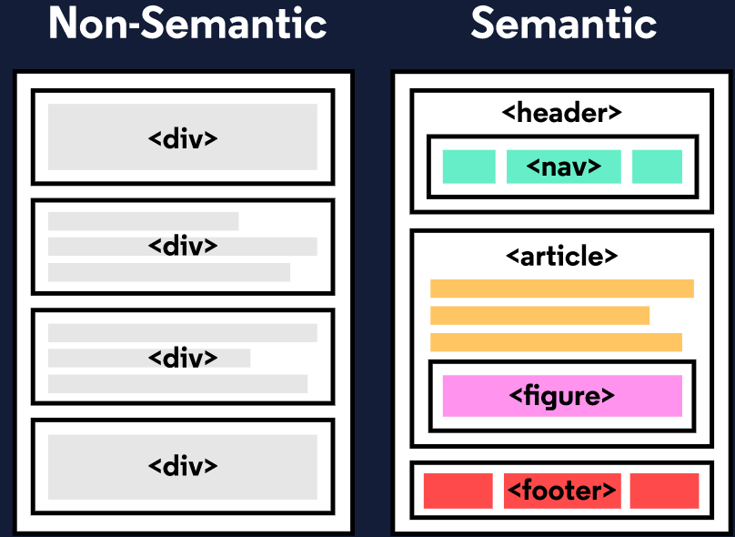

## Header and Nav

Let’s take a look at some semantic elements that assist in the structure of a web page. A <header> is a container usually for either navigational links or introductory content containing <h1> to <h6> headings.

Example:

```r
#  <header>
#    <h1>
#       Welcome to my website!
#    </h1>
#  </header>
```

This can be compared to the code below which uses a <div> tag instead of a <header> tag:

```r
#  <div id="header">
#    <h1>
#      Welcome to my website!
#    </h1>
#  </div>
```

By using a <header> tag, our code becomes easier to read. It is much easier to identify what is inside of the <h1>‘s parent tags, as opposed to a <div> tag which would provide no details as to what was inside of the tag.

A **<nav>** is used to define a block of navigation links such as menus and tables of contents. It is important to note that <nav> can be used inside of the <header> element but can also be used on its own.

Let’s take a look at the example below:

```r
#  <header>
#    <nav>
#      <ul>
#        <li><a href="#home">Home</a></li>
#        <li><a href="#about">About</a></li>
#      </ul>
#    </nav>
#  </header>
```

By using <nav> as a way to label our navigation links, it will be easier for not only us, but also for web browsers and screen readers to read the code.

## Main and Footer

Two more structural elements are **<main>** and **<footer>**. These elements along with <nav> and <header> help describe where an element is located based on conventional web development standards.

The element <main> is used to encapsulate the dominant content within a webpage. This tag is separate from the <footer> and the <nav> of a web page since these elements don’t contain the principal content. By using <main> as opposed to a <div> element, screen readers and web browsers are better able to identify that whatever is inside of the tag is the bulk of the content.

So how does <main> look when incorporated into our code?

```r
#  <main>
#    <header>
#      <h1>Types of Sports</h1>
#    </header>

#    <article>
#      <h3>Baseball</h3>
#      <p>
#        The first game of baseball was played in Cooperstown, New York in the summer of 1839.
#      </p>
#    </article>

#  </main>
```

As we see above, <main> contains an <article> and <header> tag with child elements that hold the most important information related to the page.

The content at the bottom of the subject information is known as the footer, indicated by the <footer> element. The footer contains information such as:

- Contact information
- Copyright information
- Terms of use
- Site Map
- Reference to top of page links

For example:

```r
#  <footer>
#    <p>Email me at diego.lopez@colmex.mx</p>
#  </footer>
```

In the example above, the footer is used to contain contact information. The <footer> tag is separate from the <main> element and typically located at the bottom of the content.

## Article and Section

Now that we covered the body of Semantic HTML, let’s focus on what can go in the body. The two elements we’re going to focus on now are **<section>** and **<article>**.

<section> defines elements in a document, such as chapters, headings, or any other area of the document with the same theme. For example, content with the same theme such as articles about some common theme can go under a single <section>. A website’s home page could be split into sections for the introduction, news items, and contact information.

Here is an example of how to use <section>:

```r
#  <section>
#    <h2>Section of my website (Contact) </h2>
#  </section>
```

In the code above we created a <section> element to encapsulate the code. In <section> we added a <h2> element as a heading.

The <article> element holds content that makes sense on its own. <article> can hold content such as articles, blogs, comments, magazines, etc. An <article> tag would help someone using a screen reader understand where the article content (that might contain a combination of text, images, audio, etc.) begins and ends.

Here is an example of how to use <article>:

```r
#  <section>
#    <h2>Fun Facts About Cricket</h2>
#    <article>
#      <p>A single match of cricket can last up to 5 days.</p>
#    </article>
#  </section>
```

In the code above, the <article> element containing a fact about cricket was placed inside of the <section> element. It is important to note that a <section> element could also be placed in an <article> element depending on the context.

# The Aside Element

The <aside> element is used to mark additional information that can enhance another element but isn’t required in order to understand the main content. This element can be used alongside other elements such as <article> or <section>. Some common uses of the <aside> element are for:

- Bibliographies
- Endnotes
- Comments
- [Pull quotes](https://en.wikipedia.org/wiki/Pull_quote)
- Editorial sidebars -Additional information

Here’s an example of <aside> being used alongside <article>:

```r
#  <article>
#    <p>The first World Series was played between Pittsburgh and Boston in 1903 and was a nine-game series.</p>
#  </article>
#  <aside>
#    <p>
#     Babe Ruth once stated, “Heroes get remembered, but legends never die.”
#    </p>
#  </aside>
```

As shown above, the information within the <article> is the important content. Meanwhile the information within the <aside> enhances the information in <article> but is not required in order to understand it.

# Figure and Figcaption

With <aside>, we learned that we can put additional information next to a main piece of content, but what if we wanted to add an image or illustration? That is where <figure> and <figcaption> come in. <figure> is an element used to encapsulate media such as an image, illustration, diagram, code snippet, etc, which is referenced in the main flow of the document.

```r
#  <figure>
#    <img src="image.jpg"/>
#    <figcaption>This picture shows ...</figcaption>
#  </figure>
```

In this code, we created a <figure> element so that we can encapsulate our <img> tag. In <figure> we used the <img> tag to insert an image onto the webpage. We used the **src** attribute within the <img> tag so that we can link the source of the image.

It’s possible to add a caption to the image by using <figcaption>. <figcaption> is an element used to describe the media in the <figure> tag. Usually, <figcaption> will go inside <figure>. This is different than using a <p> element to describe the content; if we decide to change the location of <figure>, the paragraph tag may get displaced from the figure while a <figcaption> will move with the figure. This is useful for grouping an image with a caption.

In the example above, we added a <figcaption> into the <figure> element to describe the image from the previous example. This helps group the <figure> content with the <figcaption> content.

While the content in <figure> is related to the main flow of the document, its position is independent. This means that you can remove it or move it somewhere else without affecting the flow of the document.

## Audio and Attributes

Now that we learned about text-based content, let us dig into <audio>. The <audio> element is used to embed audio content into a document. Like <video>, <audio> uses src to link the audio source.

```r
#  <audio>
#    <source src="audiofile.mp3" type="audio/mp3">
#  </audio>
```

In this example, we created an <audio> element. Then we created a <source> element to encapsulate our audio link. In this case, audiofile.mp3 is our audio file. Then we specified the type by using type and named what kind of audio it is. Although not always necessary, it’s recommended that we state the type of audio as it helps the browser identify it more easily and determine if that type of audio file is supported by the browser.

We linked our audio file into the browser but now we need to give it controls. This is where attributes come in. Attributes provide additional information about an element. Attributes allow us to do many different things to our audio file. There are many attributes for <audio> but today we’re going to be focusing on **controls** and **src**.

- controls: automatically displays the audio controls into the browser such as play and mute.
- src: specifies the URL of the audio file.

As you might have noticed, we already used the src attribute. Most attributes go in the opening tag of <audio>. For example, here’s how we could add both autoplay functionality and audio controls:

```r
# <audio autoplay controls>
```

You can find other attributes here: [Useful attributes](https://developer.mozilla.org/en-US/docs/Web/HTML/Element/audio#Attributes)

## Video and Embed

As demonstrated in the previous exercise, media content can be a useful addition to a website. By using a <video> element, we can add videos to our website. The **<video>** element makes it clear that a developer is attempting to display a video to the user.

Some attributes that can alter a video playback include:

- controls: When added in, a play/pause button will be added onto the video along with volume control and a fullscreen option.
- autoplay: The attribute which results in a video automatically playing as soon as the page is loaded.
- loop: This attribute results in the video continuously playing on repeat.

Below is an example of <video> being used with the controls attribute:

```r
#  <video src="coding.mp4" controls>Video not supported</video>
```

In the code above, a video file named coding.mp4 is being played. The “Video not supported” will only show up if the browser is unable to display the video.

Another tag that can be used to incorporate media content into a page is the **<embed>** tag, which can embed any media content including videos, audio files, and gifs from an external source. This means that websites that have an embed button have some form of media content that can be added to other websites. The <embed> tag is a self-closing tag, unlike the <video> element.

Below we’ll take a look at <embed>:

```r
#  <embed src="download.gif"/>
```

In the example above, <embed> is being used to add in a gif from a local file known as download.gif. Embed can be used to add local files as well as media content straight from some other websites.

## Review of semantic HTML.

Now that you know the benefits of Semantic HTML and how to use it, you can incorporate semantic elements into your website to make it more accessible and to make the code easier to read.

- Semantic HTML introduces meaning to a page through specific elements that provide context as to what is in between the tags.
- Semantic HTML is a modern standard and makes a website accessible for people who use screen readers to translate the webpage and improves your website’s SEO.
- <header>, <nav> , <main> and <footer> create the basic structure of the webpage.
- <section> defines elements in a document, such as chapters, headings, or any other area of the document with the same theme.
- <article> holds content that makes sense on its own such as articles, blogs, comments, etc.
- <aside> contains information that is related to the main content, but not required in order to understand the dominant information.
- <figure> encapsulates all types of media.
- <figcaption> is used to describe the media in <figure>.
- <video>, <embed>, and <audio> elements are used for media files.

# Thank you.

If you have made it so far (or mayble you just skipped until this section to see what’s about), I hope you have now a better understanding of the basic structure of HTML. The aim of this small course is to give you the tools needed to understand more complex HTML code and be able to modify templates on your own. We have not covered styling with CSS but that requires a more technical approach. Still, you now are able to modify complex and stylished templates with a CSS file embeded without problem.

There are many more things to learn about this language that may help you in your activities as an student, economist, quant or any other science. Share this with others and all your feedback is welcome. **Thank you. Sincerely Diego López Tamayo**

[^1]: El Colegio de México, diego.lopez@colmex.mx